# Boqian_Mao_Biostat_620_HW1

Author

Boqian Mao

## Q1

```r
library(readr)
library(dplyr)
library(ggplot2)
pm2005 <- read.csv("MI_05.csv")
pm2025 <- read.csv("MI_25.csv")
```

```r
dim(pm2005)
```

```
[1] 5280   22
```

```r
dim(pm2025)
```

```
[1] 9934   22
```

```r
str(pm2005)
```

```
'data.frame':   5280 obs. of  22 variables:
 $ Date                          : chr  "01/01/2005" "01/02/2005" "01/03/2005" "01/04/2005" ...
 $ Source                        : chr  "AQS" "AQS" "AQS" "AQS" ...
 $ Site.ID                       : int  260050003 260050003 260050003 260050003 260050003 260050003 260050003 260050003 260050003 260050003 ...
 $ POC                           : int  1 1 1 1 1 1 1 1 1 1 ...
 $ Daily.Mean.PM2.5.Concentration: num  9.3 7 15.7 13.4 5.3 4 12.6 29 15.5 13.2 ...
 $ Units                         : chr  "ug/m3 LC" "ug/m3 LC" "ug/m3 LC" "ug/m3 LC" ...
 $ Daily.AQI.Value               : int  51 39 63 59 29 22 58 88 63 59 ...
 $ Local.Site.Name               : chr  "966 32nd St (Holland)" "966 32nd St (Holland)" "966 32nd St (Holland)" "966 32nd St (Holland)" ...
 $ Daily.Obs.Count               : int  1 1 1 1 1 1 1 1 1 1 ...
 $ Percent.Complete              : num  100 100 100 100 100 100 100 100 100 100 ...
 $ AQS.Parameter.Code            : int  88101 88101 88101 88101 88101 88101 88101 88101 88101 88101 ...
 $ AQS.Parameter.Description     : chr  "PM2.5 - Local Conditions" "PM2.5 - Local Conditions" "PM2.5 - Local Conditions" "PM2.5 - Local Conditions" ...
 $ Method.Code                   : int  118 118 118 118 118 118 118 118 118 118 ...
 $ Method.Description            : chr  "R & P Model 2025 PM2.5 Sequential w/WINS" "R & P Model 2025 PM2.5 Sequential w/WINS" "R & P Model 2025 PM2.5 Sequential w/WINS" "R & P Model 2025 PM2.5 Sequential w/WINS" ...
 $ CBSA.Code                     : int  26090 26090 26090 26090 26090 26090 26090 26090 26090 26090 ...
 $ CBSA.Name                     : chr  "Holland, MI" "Holland, MI" "Holland, MI" "Holland, MI" ...
 $ State.FIPS.Code               : int  26 26 26 26 26 26 26 26 26 26 ...
 $ State                         : chr  "Michigan" "Michigan" "Michigan" "Michigan" ...
 $ County.FIPS.Code              : int  5 5 5 5 5 5 5 5 5 5 ...
 $ County                        : chr  "Allegan" "Allegan" "Allegan" "Allegan" ...
 $ Site.Latitude                 : num  42.8 42.8 42.8 42.8 42.8 ...
 $ Site.Longitude                : num  -86.1 -86.1 -86.1 -86.1 -86.1 ...
```

```r
str(pm2025)
```

```
'data.frame':   9934 obs. of  22 variables:
 $ Date                          : chr  "01/01/2025" "01/02/2025" "01/03/2025" "01/04/2025" ...
 $ Source                        : chr  "AQS" "AQS" "AQS" "AQS" ...
 $ Site.ID                       : int  260050003 260050003 260050003 260050003 260050003 260050003 260050003 260050003 260050003 260050003 ...
 $ POC                           : int  1 1 1 1 1 1 1 1 1 1 ...
 $ Daily.Mean.PM2.5.Concentration: num  3.7 4.5 3.8 3.3 4.6 3.3 3 2.8 7.7 17.7 ...
 $ Units                         : chr  "ug/m3 LC" "ug/m3 LC" "ug/m3 LC" "ug/m3 LC" ...
 $ Daily.AQI.Value               : int  21 25 21 18 26 18 17 16 43 67 ...
 $ Local.Site.Name               : chr  "966 32nd St (Holland)" "966 32nd St (Holland)" "966 32nd St (Holland)" "966 32nd St (Holland)" ...
 $ Daily.Obs.Count               : int  1 1 1 1 1 1 1 1 1 1 ...
 $ Percent.Complete              : num  100 100 100 100 100 100 100 100 100 100 ...
 $ AQS.Parameter.Code            : int  88101 88101 88101 88101 88101 88101 88101 88101 88101 88101 ...
 $ AQS.Parameter.Description     : chr  "PM2.5 - Local Conditions" "PM2.5 - Local Conditions" "PM2.5 - Local Conditions" "PM2.5 - Local Conditions" ...
 $ Method.Code                   : int  170 170 170 170 170 170 170 170 170 170 ...
 $ Method.Description            : chr  "Met One BAM-1020 Mass Monitor w/VSCC" "Met One BAM-1020 Mass Monitor w/VSCC" "Met One BAM-1020 Mass Monitor w/VSCC" "Met One BAM-1020 Mass Monitor w/VSCC" ...
 $ CBSA.Code                     : int  26090 26090 26090 26090 26090 26090 26090 26090 26090 26090 ...
 $ CBSA.Name                     : chr  "Holland, MI" "Holland, MI" "Holland, MI" "Holland, MI" ...
 $ State.FIPS.Code               : int  26 26 26 26 26 26 26 26 26 26 ...
 $ State                         : chr  "Michigan" "Michigan" "Michigan" "Michigan" ...
 $ County.FIPS.Code              : int  5 5 5 5 5 5 5 5 5 5 ...
 $ County                        : chr  "Allegan" "Allegan" "Allegan" "Allegan" ...
 $ Site.Latitude                 : num  42.8 42.8 42.8 42.8 42.8 ...
 $ Site.Longitude                : num  -86.1 -86.1 -86.1 -86.1 -86.1 ...
```

```r
head(pm2005)
```

```
        Date Source   Site.ID POC Daily.Mean.PM2.5.Concentration    Units
1 01/01/2005    AQS 260050003   1                            9.3 ug/m3 LC
2 01/02/2005    AQS 260050003   1                            7.0 ug/m3 LC
3 01/03/2005    AQS 260050003   1                           15.7 ug/m3 LC
4 01/04/2005    AQS 260050003   1                           13.4 ug/m3 LC
5 01/05/2005    AQS 260050003   1                            5.3 ug/m3 LC
6 01/06/2005    AQS 260050003   1                            4.0 ug/m3 LC
  Daily.AQI.Value       Local.Site.Name Daily.Obs.Count Percent.Complete
1              51 966 32nd St (Holland)               1              100
2              39 966 32nd St (Holland)               1              100
3              63 966 32nd St (Holland)               1              100
4              59 966 32nd St (Holland)               1              100
5              29 966 32nd St (Holland)               1              100
6              22 966 32nd St (Holland)               1              100
  AQS.Parameter.Code AQS.Parameter.Description Method.Code
```

[output cut: 27 more lines]

```r
tail(pm2005)
```

```
           Date Source   Site.ID POC Daily.Mean.PM2.5.Concentration    Units
5275 09/01/2005    AQS 261639901   1                           12.8 ug/m3 LC
5276 09/07/2005    AQS 261639901   1                           30.4 ug/m3 LC
5277 09/13/2005    AQS 261639901   1                           46.5 ug/m3 LC
5278 09/25/2005    AQS 261639901   1                           24.4 ug/m3 LC
5279 10/01/2005    AQS 261639901   1                           24.0 ug/m3 LC
5280 10/07/2005    AQS 261639901   1                            2.9 ug/m3 LC
     Daily.AQI.Value Local.Site.Name Daily.Obs.Count Percent.Complete
5275              58                               1              100
5276              91                               1              100
5277             128                               1              100
5278              80                               1              100
5279              79                               1              100
5280              16                               1              100
     AQS.Parameter.Code              AQS.Parameter.Description Method.Code
```

[output cut: 27 more lines]

```r
head(pm2025)
```

```
        Date Source   Site.ID POC Daily.Mean.PM2.5.Concentration    Units
1 01/01/2025    AQS 260050003   1                            3.7 ug/m3 LC
2 01/02/2025    AQS 260050003   1                            4.5 ug/m3 LC
3 01/03/2025    AQS 260050003   1                            3.8 ug/m3 LC
4 01/04/2025    AQS 260050003   1                            3.3 ug/m3 LC
5 01/05/2025    AQS 260050003   1                            4.6 ug/m3 LC
6 01/06/2025    AQS 260050003   1                            3.3 ug/m3 LC
  Daily.AQI.Value       Local.Site.Name Daily.Obs.Count Percent.Complete
1              21 966 32nd St (Holland)               1              100
2              25 966 32nd St (Holland)               1              100
3              21 966 32nd St (Holland)               1              100
4              18 966 32nd St (Holland)               1              100
5              26 966 32nd St (Holland)               1              100
6              18 966 32nd St (Holland)               1              100
  AQS.Parameter.Code AQS.Parameter.Description Method.Code
```

[output cut: 20 more lines]

```r
tail(pm2025)
```

```
           Date Source   Site.ID POC Daily.Mean.PM2.5.Concentration    Units
9929 12/26/2025 AirNow 261630100   1                            5.2 ug/m3 LC
9930 12/27/2025 AirNow 261630100   1                            5.4 ug/m3 LC
9931 12/28/2025 AirNow 261630100   1                           10.7 ug/m3 LC
9932 12/29/2025 AirNow 261630100   1                            2.4 ug/m3 LC
9933 12/30/2025 AirNow 261630100   1                            3.4 ug/m3 LC
9934 12/31/2025 AirNow 261630100   1                            6.7 ug/m3 LC
     Daily.AQI.Value      Local.Site.Name Daily.Obs.Count Percent.Complete
9929              29 Military Park (GHIB)               1              100
9930              30 Military Park (GHIB)               1              100
9931              54 Military Park (GHIB)               1              100
9932              13 Military Park (GHIB)               1              100
9933              19 Military Park (GHIB)               1              100
9934              37 Military Park (GHIB)               1              100
     AQS.Parameter.Code AQS.Parameter.Description Method.Code
```

[output cut: 20 more lines]

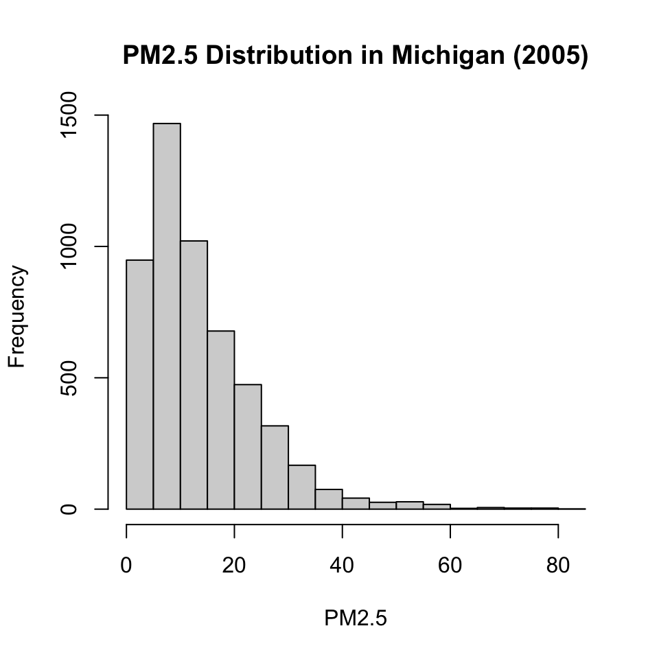

```r
hist(pm2005$Daily.Mean.PM2.5.Concentration,
     main = "PM2.5 Distribution in Michigan (2005)",
     xlab = "PM2.5")
```

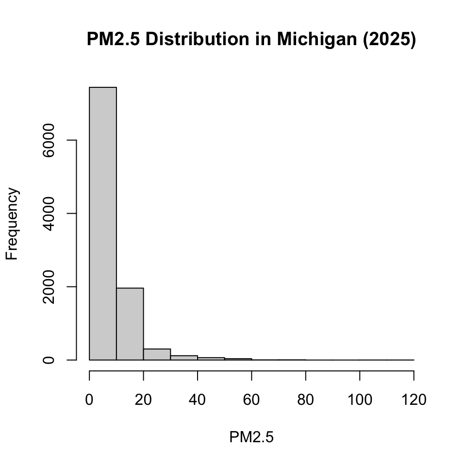

```r
hist(pm2025$Daily.Mean.PM2.5.Concentration,
     main = "PM2.5 Distribution in Michigan (2025)",
     xlab = "PM2.5")
```

There are 5280 rows and 22 columns for pm2005 and 9934 rows and 22 columns for pm2025. The observation size increased from 2005 to 2025. Examining the structure of the datasets shows that each row represents a daily PM2.5 measurement at a monitoring site in Michigan. The data appear well structured, with consistent variable names and types across the two years. Inspecting the first and last few rows of each dataset confirms that the data are ordered correctly. No obvious formatting issues or irregular values are apparent from these checks. Histograms of daily mean PM2.5 concentrations show that both distributions are right-skewed, with most observations concentrated at lower concentration levels. In 2005, PM2.5 values are more widely spread and include a larger number of high value observations. In contrast, the 2025 distribution is more heavily concentrated at lower PM2.5 values, which means improved air quality.

## Q2

```r
library(dplyr)

pm2005 <- pm2005 %>%
  mutate(year = 2005)

pm2025 <- pm2025 %>%
  mutate(year = 2025)

pm2005 <- pm2005 %>%
  rename(
    date = Date,
    pm25 = Daily.Mean.PM2.5.Concentration
  )

pm2025 <- pm2025 %>%
  rename(
    date = Date,
    pm25 = Daily.Mean.PM2.5.Concentration
  )
pm_all <- bind_rows(pm2005, pm2025)
```

## Q3

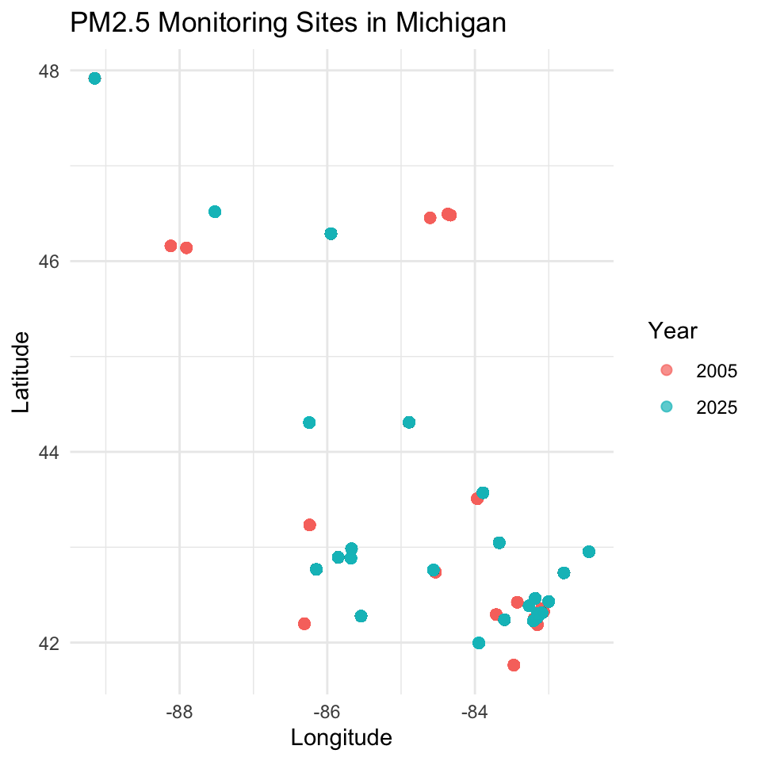

```r
library(ggplot2)

sites <- pm_all %>%
  select(Site.Latitude, Site.Longitude, year)

ggplot(sites, aes(x = Site.Longitude, y = Site.Latitude, color = factor(year))) +
  geom_point(alpha = 0.7, size = 2) +
  labs(
    title = "PM2.5 Monitoring Sites in Michigan",
    x = "Longitude",
    y = "Latitude",
    color = "Year") +
  theme_minimal()
```

The map shows that the monitoring sites are primarily located in the Lower Peninsula, with relatively few sites in more northern regions of the state. A higher concentration of sites is observed in southeastern Michigan, and western and central areas contain fewer. Comparing the two years, the overall spatial pattern of monitoring sites are very similar. Many site locations overlap between 2005 and 2025, which means that a same set of monitoring stations has been used over time. Although there are some differences in the total number of sites, there is no clear evidence of a clear change in the geographic distribution of monitoring sites between 2005 and 2025.

## Q4

```r
pm_all %>%
  group_by(year) %>%
  summarise(
    missing_pm25 = sum(is.na(pm25))
  )
```

```
# A tibble: 2 × 2
   year missing_pm25
  <dbl>        <int>
1  2005            0
2  2025            0
```

```r
pm_all %>%
  group_by(year) %>%
  summarise(
    min_pm25 = min(pm25, na.rm = TRUE),
    max_pm25 = max(pm25, na.rm = TRUE)
  )
```

```
# A tibble: 2 × 3
   year min_pm25 max_pm25
  <dbl>    <dbl>    <dbl>
1  2005        0     81.6
2  2025        0    116
```

```r
pm_all %>%
  count(Method.Code, sort = TRUE)
```

```
  Method.Code    n
1         118 4355
2         636 3941
3          NA 2543
4         170 1741
5         638 1336
6         810  607
7         145  324
8         707  323
9         781   44
```

```r
pm_all %>%
  count(year, Method.Code) %>%
  group_by(year) %>%
  mutate(prop = n / sum(n))
```

```
# A tibble: 10 × 4
# Groups:   year [2]
    year Method.Code     n    prop
   <dbl>       <int> <int>   <dbl>
 1  2005         118  4355 0.825
 2  2005         707   274 0.0519
 3  2005         781    44 0.00833
 4  2005         810   607 0.115
 5  2025         145   324 0.0326
 6  2025         170  1741 0.175
 7  2025         636  3941 0.397
 8  2025         638  1336 0.134
 9  2025         707    49 0.00493
10  2025          NA  2543 0.256
```

The distribution of Method.Code shows that two methods dominate the dataset, which are method Code 118 and Method Code 636 . According to the Method Codetable, Method Code 118 corresponds to the R & P Model 2025 PM2.5 Sequential instrument. Method Code 636 corresponds to the Teledyne T640 instrument. There are 2543 observations have missing method codes, representing some proportion of the dataset. However, the majority of observations are associated with clearly identified methods.

A clear temporal pattern shows in the distribution of the methods. In 2005, PM2.5 measurements were dominated by Method Code 118, which accounts for approximately 82.5% of observations. In contrast, the most common method in 2025 is Code 636. Additionally, approximately 25.6% of 2025 observations have missing method codes, suggesting differences in documentation or data integration practices over time.

## Q5

### Level 1

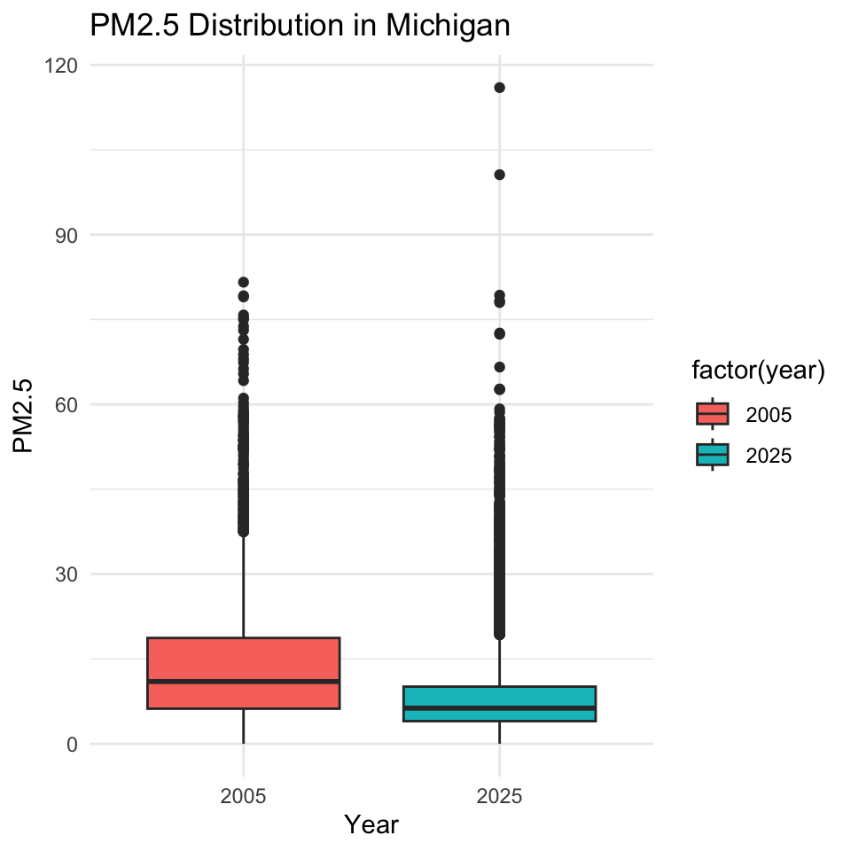

```r
ggplot(pm_all, aes(x = factor(year), y = pm25, fill = factor(year))) +
  geom_boxplot() +
  labs(
    title = "PM2.5 Distribution in Michigan",
    x = "Year",
    y = "PM2.5") +
  theme_minimal()
```

At the state level, the boxplot indicates a clear downward shift in PM2.5 concentrations from 2005 to 2025. The median concentration in 2025 is lower than in 2005, and the interquartile range appears narrower, suggesting reduced variability in daily PM2.5 levels. This indicates an overall improvement in air quality across Michigan.

### Level 2

```r
county_summary <- pm_all %>%
  group_by(County, year) %>%
  summarise(mean_pm25 = mean(pm25, na.rm = TRUE), .groups = "drop")
```

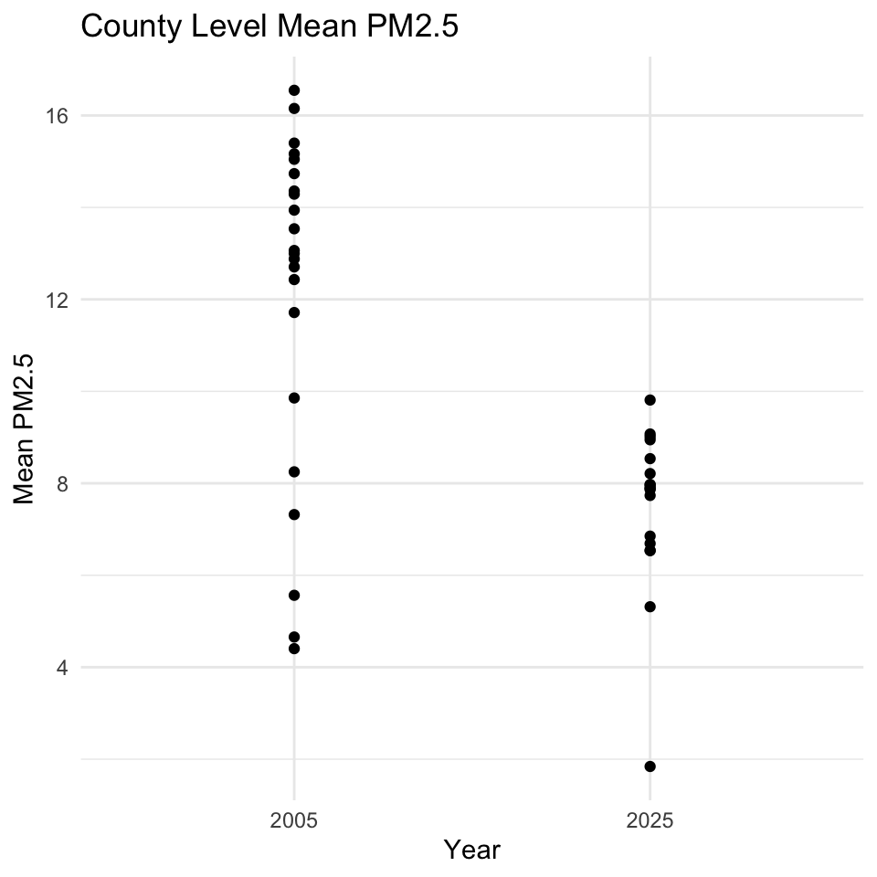

```r
ggplot(county_summary, aes(x = factor(year), y = mean_pm25, group = County)) +
  geom_point() +
  labs(
    title = "County Level Mean PM2.5",
    x = "Year",
    y = "Mean PM2.5") +
  theme_minimal()
```

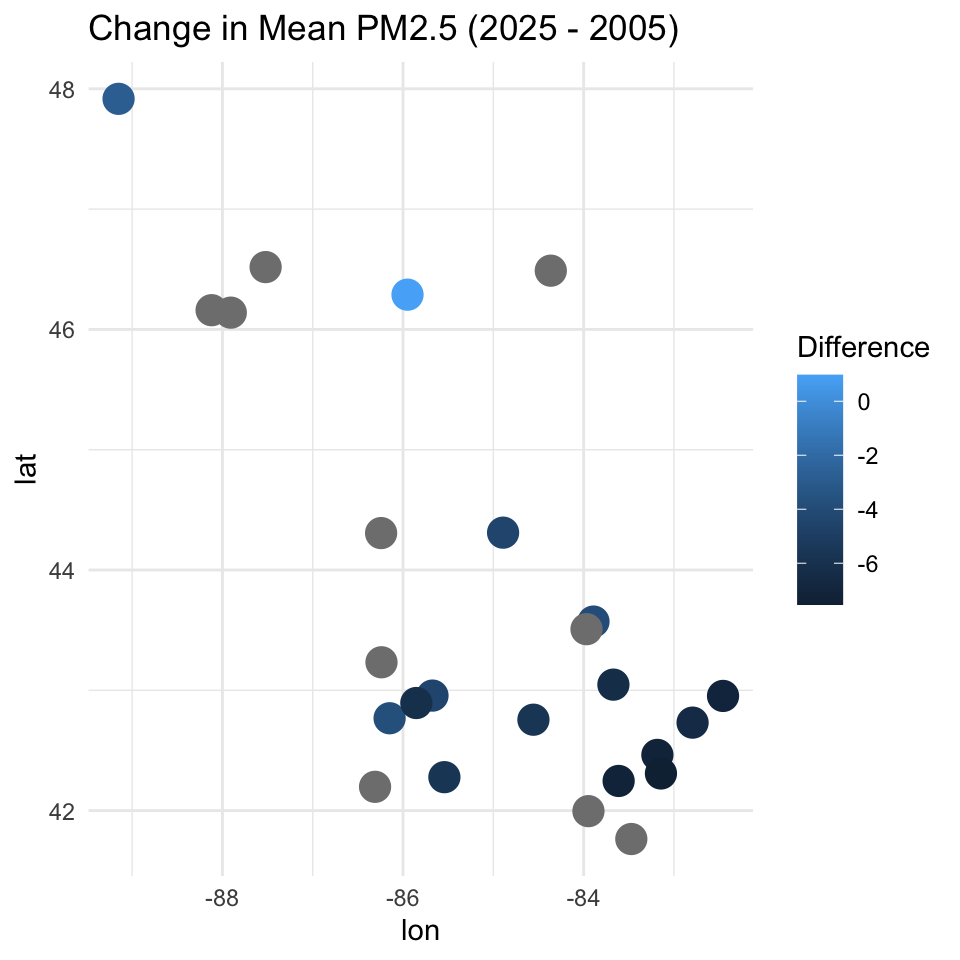

```r
library(tidyr)
county_diff <- county_summary %>%
  pivot_wider(names_from = year, values_from = mean_pm25) %>%
  mutate(diff = `2025` - `2005`)

county_locations <- pm_all %>%
  group_by(County) %>%
  summarise(
    lat = mean(Site.Latitude),
    lon = mean(Site.Longitude),
    .groups = "drop")

county_map <- left_join(county_diff, county_locations, by = "County")

ggplot(county_map, aes(x = lon, y = lat, color = diff)) +
  geom_point(size = 5) +
  labs(
    title = "Change in Mean PM2.5 (2025 - 2005)",
    color = "Difference"
  ) +
  theme_minimal()
```

At the county level, mean PM2.5 concentrations are generally lower in 2025 compared to 2005. The 2005 county level means exhibit a wider range and include several counties with high average concentrations. In contrast, 2025 county means are more tightly clustered at lower values, indicating both reduced levels and decreased variability across counties. The spatial plot of differences shows that most counties experienced negative changes, meaning that PM2.5 decreased over time. Overall, the county level analysis suggests that air quality improvements were widespread across Michigan.

### Level 3

```r
wayne_data <- pm_all %>%
  filter(County == "Wayne")

site_summary <- wayne_data %>%
  group_by(Local.Site.Name, year) %>%
  summarise(mean_pm25 = mean(pm25, na.rm = TRUE), .groups = "drop")
```

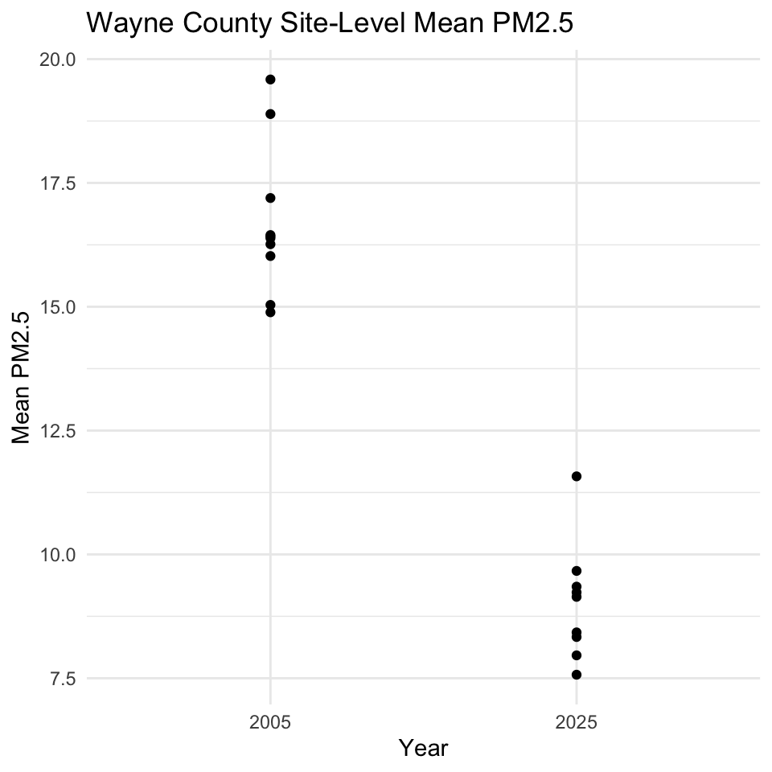

```r
ggplot(site_summary, aes(x = factor(year), y = mean_pm25, group = Local.Site.Name)) +
  geom_point() +
  labs(
    title = "Wayne County Site-Level Mean PM2.5",
    x = "Year",
    y = "Mean PM2.5") +
  theme_minimal()
```

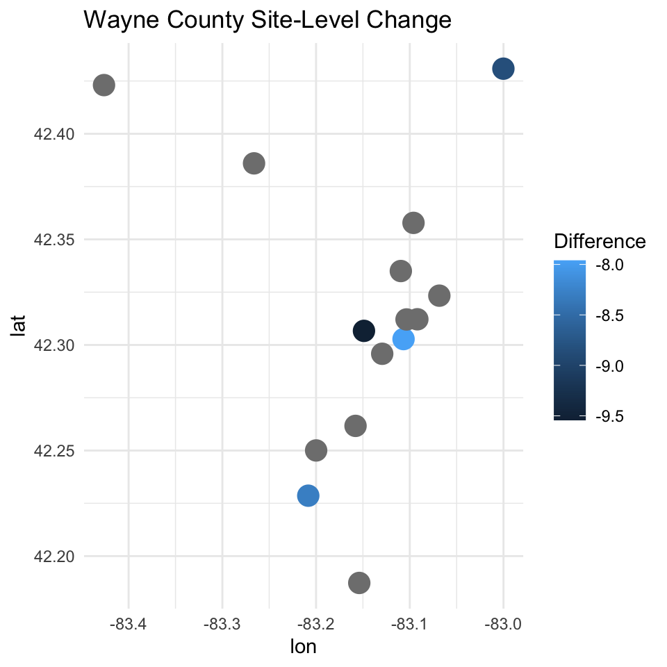

```r
wayne_sites <- wayne_data %>%
  group_by(Local.Site.Name) %>%
  summarise(
    lat = mean(Site.Latitude),
    lon = mean(Site.Longitude),
    .groups = "drop")

wayne_diff <- site_summary %>%
  pivot_wider(names_from = year, values_from = mean_pm25) %>%
  mutate(diff = `2025` - `2005`)

wayne_map <- left_join(wayne_diff, wayne_sites, by = "Local.Site.Name")

ggplot(wayne_map, aes(x = lon, y = lat, color = diff)) +
  geom_point(size = 5) +
  labs(
    title = "Wayne County Site-Level Change",
    color = "Difference") +
  theme_minimal()
```